# Lab 2

Sierra Jo Sallee

2019-08-30

# Task 1

Get working directory.

```r
getwd()
```

```
## [1] "/Users/sierrasallee/Desktop/Stats/Labs/LAB2"
```

# Task 2

Read data into R.

```r
dataTable = read.csv("/Users/sierrasallee/Desktop/Stats/Labs/DATAxls/EPAGAS.csv")

head(dataTable)
```

```
##    MPG
## 1 36.3
## 2 41.0
## 3 36.9
## 4 37.1
## 5 44.9
## 6 36.8
```

# Task 3

Create the variable mpg

```r
mpg = dataTable$MPG

zi = function(x){ # x is a vector
  n <- length(x)
  x_mean <- mean(x)
  (x - x_mean) / sd(x)
}
```

Z-transformation of mpg

```r
z = zi(mpg)
z
```

```
##   [1] -0.287026279  1.656811633 -0.038876758  0.043839749  3.269783517
##   [6] -0.080235012 -2.892596246  0.085198002  2.111752421 -0.121593265
##  [11] -1.775923403  0.126556256  1.739528140 -0.162951519 -1.693206896
##  [16] -0.204309772 -1.569132136  0.167914509  0.209272762 -1.403699122
##  [21]  1.450020366 -0.204309772  0.250631016 -1.279624361  1.325945605
##  [26] -0.245668025  0.291989269  0.291989269  1.243229098 -1.155549601
##  [31] -0.328384532  0.374705776 -0.411101039  0.374705776 -0.452459293
##  [36]  0.498780537  0.540138790 -0.535175800 -0.576534053 -0.783325320
##  [41]  0.622855297  0.829646564 -0.617892306 -0.907400081  0.664213550
##  [46]  0.995079578 -0.700608813 -1.072833094  0.746930057  1.119154338
##  [51] -0.287026279 -0.080235012 -1.858639910 -0.245668025  1.450020366
##  [56] -0.162951519 -0.369742786  0.498780537  0.581497043  0.953721324
##  [61]  1.656811633 -2.148147684  0.126556256 -1.610490389  0.002481495
##  [66]  0.250631016  0.002481495  0.705571804  0.829646564 -0.493817546
##  [71]  0.002481495  0.085198002  1.532736873  0.167914509  0.043839749
##  [76]  0.333347523 -0.452459293 -0.576534053 -0.121593265 -1.031474841
##  [81]  0.043839749  1.367303859 -0.121593265  0.002481495 -1.279624361
##  [86]  1.284587352  0.416064030 -0.741967067 -0.907400081  1.036437831
##  [91]  1.201870845 -0.038876758 -1.693206896 -1.320982615  1.160512592
##  [96] -1.238266108 -0.080235012 -0.824683574  0.457422283 -0.038876758
```

Mean value of z

```r
z_mean = round(mean(zi(mpg)), digits=2)
z_mean
```

```
## [1] 0
```

Standard deviation of z squared

```r
sz2 = sd(zi(mpg))^2
sz2
```

```
## [1] 1
```

Possible outliers

```r
possible_outliers = mpg[abs(z)>=2&abs(z)<=3]
possible_outliers[!is.na(possible_outliers)]
```

```
## [1] 30.0 42.1 31.8
```

Outliers

```r
outliers = mpg[abs(z)>3]
outliers[!is.na(outliers)]
```

```
## [1] 44.9
```

Dotplot of possible outliers, outliers, and main line values.

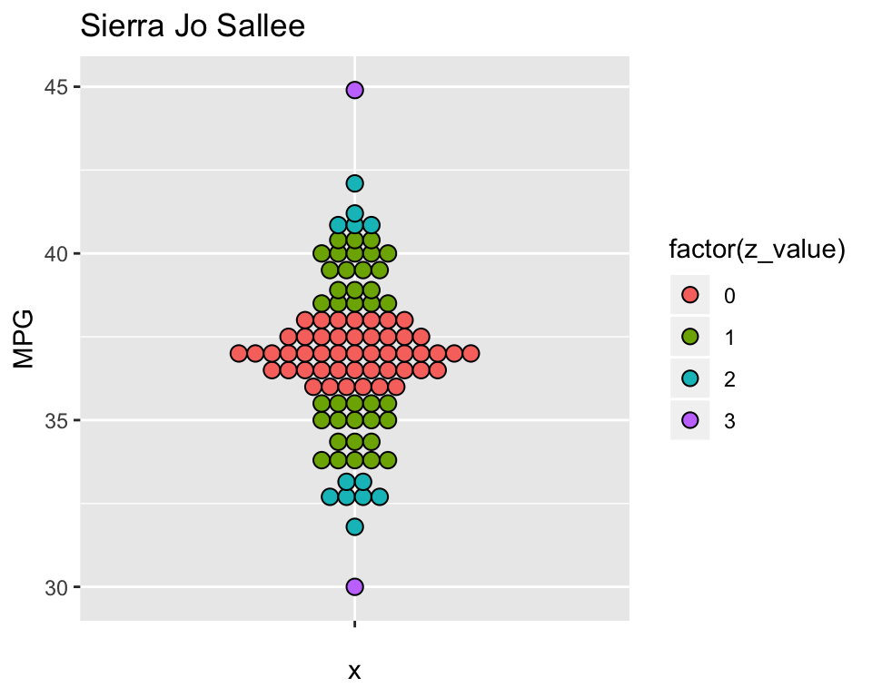

```r
z_value = abs(round(z, digits=0))

dotplot_data = data.frame(dataTable, z_value)
ggplot(dotplot_data, aes(x=" ", y=MPG, fill=factor(z_value))) +
  geom_dotplot(binaxis='y', stackdir='center') +
  ggtitle("Sierra Jo Sallee")
```

# Task 4

Make a boxplot of the mpg variable

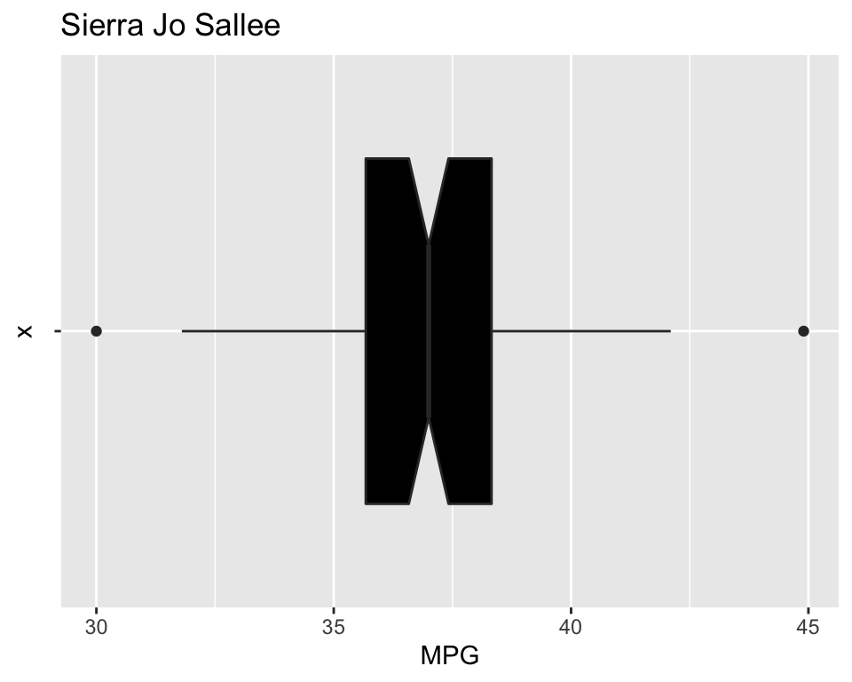

```r
dataTable = read.csv("/Users/sierrasallee/Desktop/Stats/Labs/DATAxls/EPAGAS.csv")

ggplot(dataTable, aes(x=" ", y=MPG)) +
  geom_boxplot(notch=TRUE, fill="black") +
  coord_flip() +
  ggtitle("Sierra Jo Sallee")
```

Using Chebyshev’s theorem predict the proportion of data within 2 standard deviations of the mean of the mpg data.

```r
length(mpg) * .75
```

```
## [1] 75
```

Use R to calculate the exact proportion within 2 standard deviation of the mean.

```r
c_high = mean(mpg) + (2 * sd(mpg))
c_low = mean(mpg) - (2 * sd(mpg))

length(with(dataTable, dataTable[MPG <= c_high & MPG >= c_low,]))
```

```
## [1] 96
```

Does Chebyshev agree with the data?  
Yes. Chebyshev’s rule dictates that AT LEAST 75% of the data will be within 2 standard deviations of the mean. Our data has more than 75%, but it still follows Chebyshev’s prediction.  
Now use the empirical rule, what proportion (according to the rule) of the data should be within 2 standard deviations of the mean?

```r
length(mpg) * .95
```

```
## [1] 95
```

How well does it correspond? Ther is only 1% of difference in the data from the prediction. It corresponds well.  
Is the Empirical rule valid in this case? Why? Yes. The Empirical rule states that APPROXIMATELY 95% of the data will be within 2 standard deviations of the mean. 96% is approximately 95%.